# Theming with bslib and thematic

# Introduction

This is my attempt at finding the best tree model for the healthcare prediction data that was analyzed by [`ALIA107`](https://www.kaggle.com/code/bvc5283/healthcare-prediction/notebook) on kaggle.

I will more or less try to reproduce the same effects as the user above, but refining the code, reporting language, and overall presentation of tables and figures as to make it more appealing to a general user. I will also expand the analysis when seen appropriate.

The goal is to predict whether a discharged patient will return to the hospital within 30 days.

# Infrastructure

Below I create a set of vectors that will serve as basic parameters mostly for producing tables and plots. Further, here I will set up all self-created functions. All of this helps with making the code shorter and cleaner.

## Plots

### Color Palette

```r
# https://colorhunt.co/palette/f9f7f7dbe2ef3f72af112d4e
#F9F7F7
#112D4E
#DBE2EF
#3F72AF

colors <- c(
  "#FF9843",
  "#FFDD95",
  "#86A7FC",
  "#3468C0"
)
```

## Tables

```r
own_table <- function(x) {
  x %>%
    kable() %>%
    kable_minimal(lightable_options = "hover")
}
```

# Data cleaning

Let’s take a look at the basic structure of the dataset.

```r
glimpse(healthcare)
```

```
## Rows: 38,078
## Columns: 27
## $ INDEX           <dbl> 1, 2, 3, 4, 5, 6, 7, 8, 9, 10, 11, 12, 13, 14, 15, 16,…
## $ HOSPITAL        <chr> "Hospital C", "Hospital E", "Hospital E", "Hospital B"…
## $ GENDER          <chr> "Female", "Female", "Male", "Female", "Male", "Female"…
## $ AGE             <dbl> 27, 43, 24, 24, 31, 34, 32, 39, 54, 21, 32, 23, 46, 24…
## $ RACE            <chr> "Black or African American", "Black or African America…
## $ ETHNICITY       <chr> "Not Hispanic or Latino", "Not Hispanic or Latino", "N…
## $ FINANCIAL_CLASS <chr> "MA MCO", "MA MCO", "MA MCO", "MA MCO", "Commercial", …
## $ WEEKDAY_ARR     <dbl> 3, 7, 6, 5, 7, 6, 4, 6, 6, 6, 3, 5, 5, 4, 1, 5, 7, 7, …
## $ HOUR_ARR        <dbl> 8, 20, 12, 8, 13, 14, 10, 11, 16, 18, 2, 12, 20, 14, 7…
## $ MONTH_ARR       <dbl> 8, 3, 4, 9, 9, 3, 1, 2, 9, 11, 5, 9, 9, 11, 5, 11, 5, …
## $ WEEKDAY_DEP     <dbl> 3, 7, 6, 5, 7, 6, 4, 6, 6, 6, 3, 5, 5, 4, 1, 5, 7, 7, …
## $ HOUR_DEP        <dbl> 8, 20, 12, 8, 13, 14, 10, 11, 16, 18, 2, 12, 20, 14, 7…
## $ MONTH_DEP       <dbl> 8, 3, 4, 9, 9, 3, 1, 2, 9, 11, 5, 9, 9, 11, 5, 11, 5, …
## $ SAME_DAY        <dbl> 0, 1, 1, 1, 1, 0, 1, 1, 1, 1, 1, 1, 1, 1, 1, 1, 1, 1, …
## $ ED_RESULT       <chr> "Admit", "Left prior to completing treatment", "Discha…
## $ ACUITY_ARR      <chr> "3-Urgent", "3-Urgent", "4-Less Urgent", "3-Urgent", "…
## $ DC_RESULT       <chr> "Home or Self Care", "Home or Self Care", "Home or Sel…
## $ ADMIT_RESULT    <chr> "Inpatient", NA, NA, NA, NA, "Observation", NA, NA, NA…
## $ CONSULT_ORDER   <dbl> 0, 0, 0, 0, 0, 0, 0, 0, 0, 0, 0, 0, 0, 0, 0, 0, 0, 0, …
## $ CONSULT_CHARGE  <dbl> 0, 0, 0, 0, 0, 0, 0, 0, 0, 0, 0, 0, 0, 0, 0, 0, 0, 0, …
## $ CONSULT_IN_ED   <dbl> NA, NA, NA, NA, NA, NA, NA, NA, NA, NA, NA, NA, NA, NA…
## $ DIAGNOSIS       <chr> "Yes", "Yes", "Yes", "Yes", "Yes", "Yes", "Yes", "No",…
## $ DIAG_DETAILS    <dbl> 4, 0, 0, 0, 0, 4, 0, 0, 0, 0, 0, 0, 0, 0, 0, 0, 0, 0, …
## $ RISK            <chr> "Minor", NA, NA, NA, NA, "Major", NA, NA, NA, NA, NA, …
## $ SEVERITY        <chr> "Moderate", NA, NA, NA, NA, "Major", NA, NA, NA, NA, N…
## $ CHARGES         <chr> "9709.43", "2371.55", "407.36", "3018.71", "1045.68", …
## $ RETURN          <chr> "Yes", "No", "No", "No", "No", "No", "No", "Yes", "No"…
```

The `read_csv` function, as opposed to `read.csv`, automatically ascribes `NA` to empty values.

```r
dimen <- dim(healthcare)
dimen
```

```
## [1] 38078    27
```

The raw dataset contains 38078 obsevations with 27 variables.

In order to ease coding the names of all variables are turned to lowercase.

```r
healthcare <- healthcare %>%
  rename_with(~str_to_lower(.), everything())
```

## Missing data

```r
healthcare %>%
  summarise(
    across(everything(), list(
      number = ~sum(is.na(.)),
      percent = ~mean(is.na(.))
      )
    )
  ) %>%
  pivot_longer(
    everything(),
    names_pattern = "(.*)_(.*)",
    names_to = c("Variable", "Statistic"),
    values_to = "value"
    ) %>%
  pivot_wider(names_from = Statistic, values_from = value) %>%
  mutate(percent = round(percent * 100, 1)) %>%
  arrange(desc(percent)) %>%
  filter(number != 0) -> missing

missing2 <- missing %>%
  filter(percent > 10)

missing %>%
  own_table
```

| Variable | number | percent |
| --- | --- | --- |
| consult_in_ed | 37195 | 97.7 |
| risk | 33013 | 86.7 |
| severity | 33013 | 86.7 |
| admit_result | 30587 | 80.3 |
| acuity_arr | 3257 | 8.6 |
| ethnicity | 373 | 1.0 |
| race | 177 | 0.5 |
| ed_result | 72 | 0.2 |

There are 8 variables with missing data. However, only 4 have missing values at a level of more than 10%.

We can check, if there is any pattern in missing values in relation to to the `return` (DV) variable.

[output not shown]

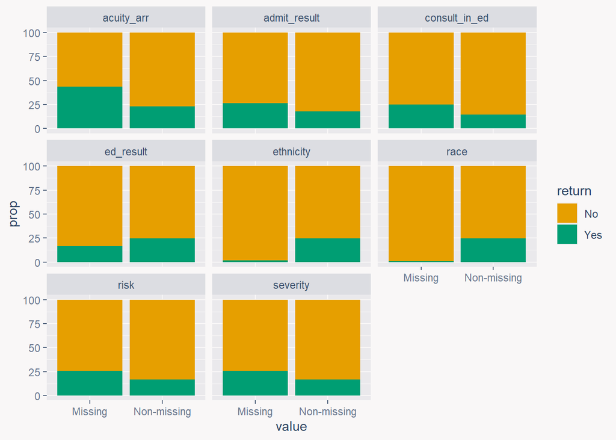

```r
missing_filt <- missing %>%
  pull(Variable)


healthcare %>%
  select(return, missing_filt) %>%
  mutate(across(-return, ~if_else(is.na(.), "Missing", "Non-missing"))) %>%
  pivot_longer(-return) %>%
  nest(.by = name) %>%
  mutate(
    freq_table = map(data, freq_table, value, return)
  ) %>%
  select(-data) %>%
  unnest() %>%
  ggplot(aes(value, prop, fill = return)) +
  geom_bar(stat = "identity") +
  facet_wrap(~name)
```

Differences in proportions of those who returned were observed in all variables that had missing values. Including them could improve the model. Therefore, in the case of character variables, `NA` will be coded as *“Missing”*.

```r
# Adding missing as a string value
healthcare <- healthcare %>%
  mutate(
    across(where(is.character), ~replace_na(., "Missing"))
  ) %>%
  select(-consult_in_ed) # Exclude the numerical variable with mostly missing values
```

## Qualitative values

### Unique values

Checking what character vectors represent by inspecting unique values.

```r
healthcare %>%
  select(where(is.character)) %>%
  map(unique) %>%
  keep(~length(.) < 50) %>%
  {
    by_length <- lengths(.) %>%
      order()
    .[by_length]
    }
```

```
## $gender
## [1] "Female" "Male"
##
## $diagnosis
## [1] "Yes" "No"
##
## $return
## [1] "Yes" "No"
##
## $hospital
## [1] "Hospital C" "Hospital E" "Hospital B" "Hospital A" "Hospital D"
##
## $ethnicity
## [1] "Not Hispanic or Latino" "Hispanic or Latino"     "Declined to Answer"
## [4] "Missing"                "Unknown"
```

[output cut: 93 more lines]

Variables like Race or Ethnicity have two values that essentially mean the same thing - *“Declined to answer”* and *Unknown*”. Both will be transformed to missing values.

The **DC** stands for discharge, while **ED** for emergency department. Both consist of a substantial number of unique values. Using them in at least some of the models (e.g. regressions) would be highly penalized, because of a large number of predictors. Further, if we strive for higher interpretability, a simpler model is preferred. Therefore, we will simplify those variables to a smaller number of levels. This will also include `race` and `financial_class`, as they also have above 10 levels.

```r
healthcare %>%
  select(financial_class, ed_result, dc_result, race) %>%
  pivot_longer(everything()) %>%
  nest(.by = name) %>%
  mutate(freq = map(data, freq_table, value)) %>%
  select(-data) %>%
  unnest() %>%
  arrange(name, desc(prop)) %>%
  filter(prop > 1) %>%
  own_table()
```

| name | value | n | prop |
| --- | --- | --- | --- |
| dc_result | Home or Self Care | 29835 | 78.4 |
| dc_result | LEFT W/O BEING SEEN AFTER TRIAGE | 2445 | 6.4 |
| dc_result | LEFT W/O BEING SEEN BEFORE TRIAGE | 1444 | 3.8 |
| dc_result | LEFT W/O COMPLETED TREATMENT | 854 | 2.2 |
| dc_result | Not specified Other or Unknown | 700 | 1.8 |
| dc_result | Home Health Care Svc | 579 | 1.5 |
| dc_result | Rehab Facility | 585 | 1.5 |
| dc_result | Left Against Medical Advice | 466 | 1.2 |
| ed_result | Discharge | 22920 | 60.2 |
| ed_result | Admit | 4356 | 11.4 |
| ed_result | LWBS after Triage | 2754 | 7.2 |
| ed_result | Observation | 2483 | 6.5 |
| ed_result | LWBS before Triage | 2244 | 5.9 |
| ed_result | Left prior to completing treatment | 1063 | 2.8 |
| ed_result | Send to L&D Before Rooming (Mom) | 678 | 1.8 |
| ed_result | AMA | 510 | 1.3 |
| financial_class | MA MCO | 18478 | 48.5 |
| financial_class | Medicare | 6670 | 17.5 |
| financial_class | Commercial | 3090 | 8.1 |
| financial_class | Self-pay | 2974 | 7.8 |
| financial_class | Blue Shield | 2690 | 7.1 |
| financial_class | Medicaid | 2262 | 5.9 |
| financial_class | Medicare Replacement Plan | 1200 | 3.2 |
| race | Black or African American | 28706 | 75.4 |
| race | White | 7849 | 20.6 |
| race | Other | 813 | 2.1 |

Based on the proportions, `dc_result` will be recoded to a variable with only two values, as the majority of the patients belonged to one category. The `ed_result` and `financial_class` variables have a more varied distribution and will be lumped up to the category with 5% of observations. In the latter case a more theoretically-oriented approach could be implemented, but it would require a higher domain-knowledge. `race` will be divided to three categories: *“Black or African American”*, *“White”* and *“Other”*.

```r
# Check if there are other, similarly formulated values as "home or self care"
healthcare$dc_result %>%
  unique() %>%
  str_subset("[hH]ome|[sS]elf")
```

```
## [1] "Home or Self Care"    "Home Health Care Svc" "Hospice/Home"
```

“Home Health Care Svc” sounds similar to “Home or Self Care”. However, as the distinction is not obvious, it will be left as it is.

```r
healthcare <- healthcare %>%
  mutate(
    across(c(ed_result, financial_class), ~fct_lump_prop(., 0.05)),
    race = fct_lump(race, 2),
    dc_result = fct_lump(dc_result, 1)
  )
```

Variable `acuity_arr` has a suspected value *“5 Purple”*, as it does not make sense in the context of the remaining values.

```r
healthcare %>%
  count(acuity_arr) %>%
  own_table()
```

| acuity_arr | n |
| --- | --- |
| 1-Immediate | 203 |
| 2-Emergent | 3704 |
| 3-Urgent | 19722 |
| 4-Less Urgent | 9349 |
| 5 Purple | 1 |
| 5-Non-Urgent | 1842 |
| Missing | 3257 |

As there is only one observation with such value, it can be safely ignored as `NA`.

```r
# Transforming remaining character vectors to factors
healthcare2 <- healthcare %>%
  mutate(
    acuity_arr = mapvalues(acuity_arr, "5 Purple", "Missing" ),
    acuity_arr = factor(acuity_arr) %>% fct_relabel(~str_replace(., "[0-9]-", "")),
    across(c(race, ethnicity), ~plyr::mapvalues(
      .,
      from = c( "Declined to Answer","Unknown"),
      to = c("Missing", "Missing")
      )
    ),
    across(
      c(hospital, gender, race, ethnicity, diagnosis, return, financial_class, admit_result),
      ~as.factor(.)
      ),
    across(c(risk, severity), ~factor(., levels = c("Minor","Moderate", "Major", "Extreme", "Missing"))),
    across(
      c(race, financial_class, admit_result, ethnicity),
      ~fct_relevel(., "Missing", "Other", after = Inf)) # Move "other" to the end
  )
healthcare2 %>%
  select(where(is.factor)) %>%
  map(levels)
```

```
## $hospital
## [1] "Hospital A" "Hospital B" "Hospital C" "Hospital D" "Hospital E"
##
## $gender
## [1] "Female" "Male"
##
## $race
## [1] "Black or African American" "White"
## [3] "Other"
##
## $ethnicity
## [1] "Hispanic or Latino"     "Not Hispanic or Latino" "Missing"
##
## $financial_class
## [1] "Blue Shield" "Commercial"  "MA MCO"      "Medicaid"    "Medicare"
## [6] "Self-pay"    "Other"
##
## $ed_result
## [1] "Admit"              "Discharge"          "LWBS after Triage"
## [4] "LWBS before Triage" "Observation"        "Other"
##
## $acuity_arr
## [1] "Immediate"   "Emergent"    "Urgent"      "Less Urgent" "Non-Urgent"
## [6] "Missing"
##
## $dc_result
## [1] "Home or Self Care" "Other"
##
## $admit_result
## [1] "Inpatient"        "Observation"      "Psych Inpatient"  "Trauma Inpatient"
## [5] "Missing"
##
## $diagnosis
## [1] "No"  "Yes"
##
## $risk
## [1] "Minor"    "Moderate" "Major"    "Extreme"  "Missing"
##
## $severity
## [1] "Minor"    "Moderate" "Major"    "Extreme"  "Missing"
##
## $return
## [1] "No"  "Yes"
```

# EDA

## Analysis of qualitative variables

[output not shown]

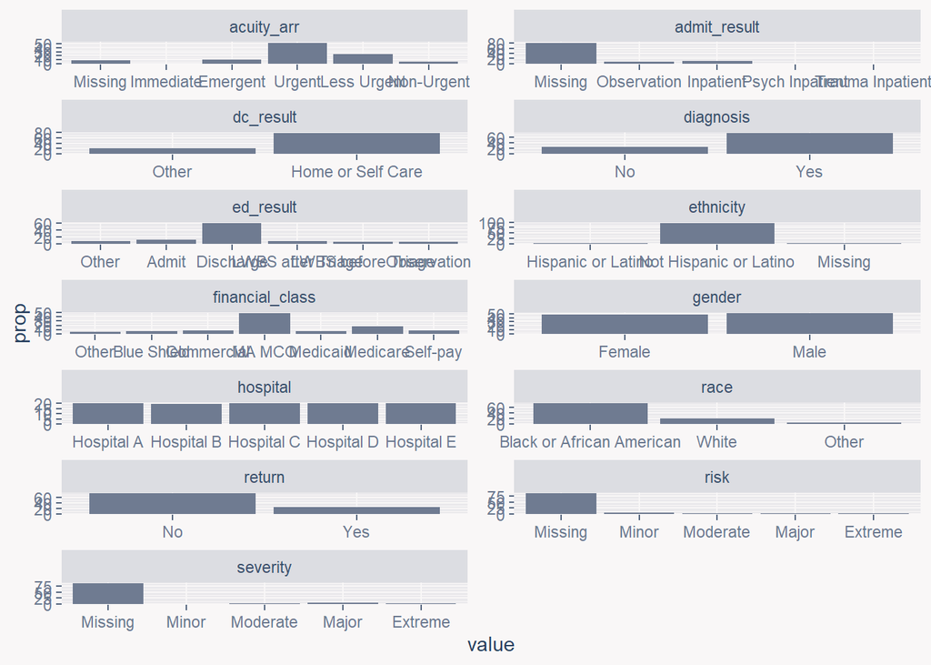

```r
healthcare2 %>%
  select(return, where(is.factor)) %>%
  pivot_longer(everything()) %>%
  nest(.by = name) %>%
  mutate(freq = map(data, freq_table, value)) %>%
  unnest(.by = freq) %>%
  ggplot(aes(value, prop)) +
  geom_bar(stat = "identity") +
  facet_wrap(~name, scales = "free", ncol = 2 )
```

## Exploration of quantitative variables